# Week 3

The data for this week’s analysis is from the UCI Machine Learning Repository: [link to the data source](https://archive.ics.uci.edu/ml/datasets/STUDENT+ALCOHOL+CONSUMPTION).

The data has 33 different variables (questions). Many variables are binary values, such as school, which is answered by the student either as GP (Gabriel Pereira) or MS (Mousinho da Silveira). Also family size is binary: LE3 is less or equal to 3, GT3 is greater than 3. Some binary variables are just answered either yes or no. There are some other variables that are answered by number, such as age that is answered by integer, number from 15-22. Also some questions are answered nominally, such as mother’s job. In the end there is G1, G2 and G3, which are the numeric grades from periods 1, 2 and the final grade from student’s course subject, Math or Portuguese. There are many background questions and questions related to studying, but also questions about alcohol consumption during the workdays and weekends.

The largest difference from the original data and the data table presented here (Table 1) is the two extra columns we have added here after grade variables, which are about alcohol use and high use of alcohol. The alcohol use combines the two original questions Dalc (workday alcohol consumption) and Walc (weekend alcohol consumption), which were estimated in numbers from 1-5, 1 being low use and 5 high, and gives an average of those. The high use is true for students whose combined alcohol use was more than 2. So in our data table we have 35 variables instead of 33 original ones. Also the data has been modified in the data wrangling the two different questionnaires have been merged to one, combining the data files and excluding the possible duplicate answers if one student has taken both questionnaires.

**Table 1.** Variables in the combined data file.

```r
alc<-read.table("~/Tiedostot_J/IODS-project/data/alc.txt", sep="", header=TRUE)

colnames(alc)
```

```
##  [1] "school"     "sex"        "age"        "address"    "famsize"
##  [6] "Pstatus"    "Medu"       "Fedu"       "Mjob"       "Fjob"
## [11] "reason"     "nursery"    "internet"   "guardian"   "traveltime"
## [16] "studytime"  "failures"   "schoolsup"  "famsup"     "paid"
## [21] "activities" "higher"     "romantic"   "famrel"     "freetime"
## [26] "goout"      "Dalc"       "Walc"       "health"     "absences"
## [31] "G1"         "G2"         "G3"         "alc_use"    "high_use"
```

The purpose of our analysis is to study relationships between some variables in the data set and alcohol consumption. For this purpose, I have chosen four variables that could have been effected by how much student is using alcohol in his/her life. Two variables are likely to be positively affected by low alcohol consumption and values of two variables should increase if the student consumes more alcohol. The low alcohol consumption could possible increase the quality of family relationships and weekly study time. The high alcohol consumption could have an effect on amounts of absences in school and going out more often with friends. So, I have chosen the following four variables for further analysis:

These variables will be analyzed with high usage of alcohol, so the first graph should show low relationship with family when students are using high amounts of alcohol (TRUE in the graph), another should be also lower than for the students not using high amounts of alcohol (FALSE). In the two last figures it should be other way around, for high alcohol consumption the box should be higher than for low alcohol consumers.

In the **data table 1** there is the number of those students who are consuming higher amounts of alcohol (high alcohol consumption = TRUE) and those who are consuming less (high alcohol consumption = FALSE). In the **data table 2** there are the mean values of family relationships in the high alcohol consuming group (TRUE) and less alcohol consuming group (FALSE).

**Boxplot 1.** An effect of student’s alcohol consumption on family relationships.

```r
#access to libraries tidyr, dplyr and ggplot2. Had to suppress dplyr startupmessage.
suppressPackageStartupMessages({
library("dplyr")
})
library(dplyr)
library(tidyr)
library(ggplot2)

# produce summary statistics by group. How many from students are in the high alcohol consumption group?
alc %>% group_by(high_use) %>% summarise(count = n())
```

```
## # A tibble: 2 × 2
##   high_use count
##      <lgl> <int>
## 1    FALSE   268
## 2     TRUE   114
```

```r
# What is the mean value of family relationship values in low consumer's group?
alc %>% group_by(high_use) %>% summarise(mean_grade=mean(famrel))
```

```
## # A tibble: 2 × 2
##   high_use mean_grade
##      <lgl>      <dbl>
## 1    FALSE   4.003731
## 2     TRUE   3.780702
```

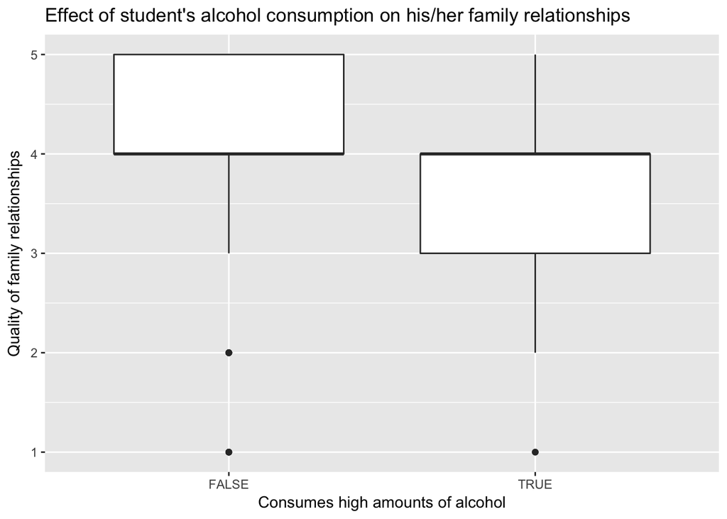

```r
# initialize a box plot of high_use and famrel, studytime, goout and absences.
g1<-ggplot(alc, aes(x=high_use, y=famrel))

# define the plot as a boxplot and draw it
g1 + geom_boxplot() + ylab("Quality of family relationships")+xlab("Consumes high amounts of alcohol")+ggtitle("Effect of student's alcohol consumption on his/her family relationships")
```

So it seems that the alcohol consumption possibly very small effect on quality of the family relationships. For those who did not use high amounts of alcohol estimated their family relationships to 4.0 (average) and those who used high amounts, the average value was 3.8.

In the **data table 3** there are the mean values of the time the students are using in the high alcohol consuming group (TRUE) and less alcohol consuming group (FALSE).

**Boxplot 2.** An effect of student’s alcohol consumption on time used studying.

```r
#access to libraries tidyr, dplyr and ggplot2.
library(tidyr); library(dplyr); library(ggplot2)

# What is the mean time used for studies in high/low consumer's group?
alc %>% group_by(high_use) %>% summarise(mean_grade=mean(studytime))
```

```
## # A tibble: 2 × 2
##   high_use mean_grade
##      <lgl>      <dbl>
## 1    FALSE   2.149254
## 2     TRUE   1.771930
```

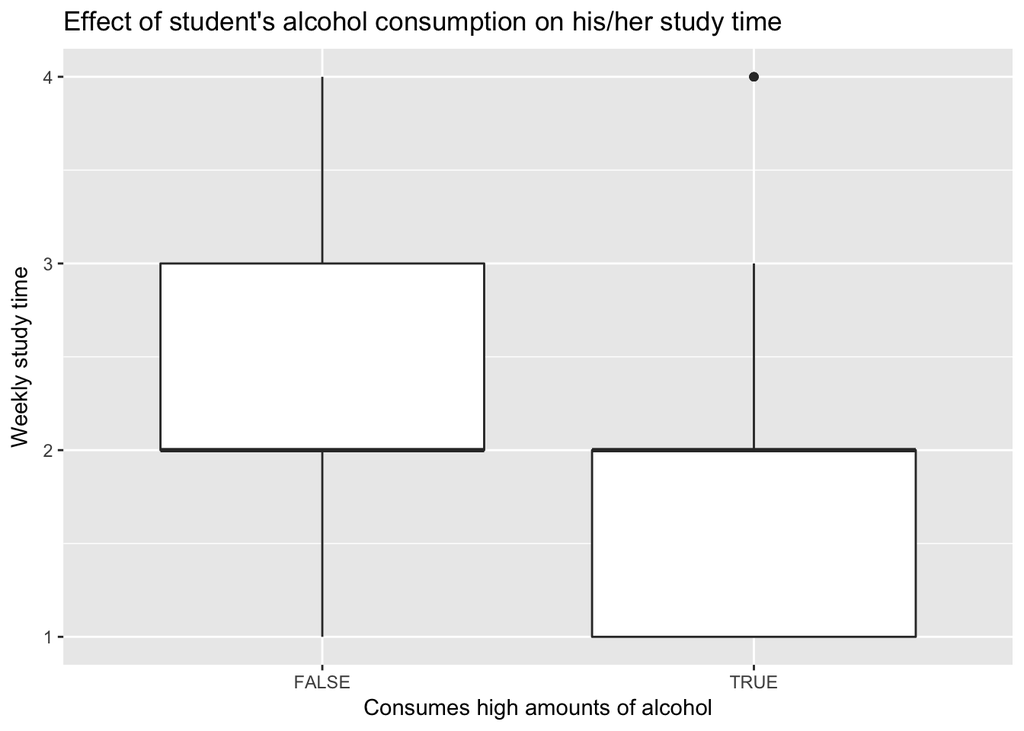

```r
g2<-ggplot(alc, aes(x=high_use, y=studytime))
g2 + geom_boxplot() + ylab("Weekly study time")+xlab("Consumes high amounts of alcohol")+ggtitle("Effect of student's alcohol consumption on his/her study time")
```

In the **data table 4** there are the mean values of the time the students are spending out with their friends in the high alcohol consuming group (TRUE) and less alcohol consuming group (FALSE).

**Boxplot 3.** An effect of student’s alcohol consumption on time spended out with their friends.

```r
#access to libraries tidyr, dplyr and ggplot2.
library(tidyr); library(dplyr); library(ggplot2)

# What is the going out with friends in high/low consumer's group?
alc %>% group_by(high_use) %>% summarise(mean_grade=mean(goout))
```

```
## # A tibble: 2 × 2
##   high_use mean_grade
##      <lgl>      <dbl>
## 1    FALSE   2.854478
## 2     TRUE   3.719298
```

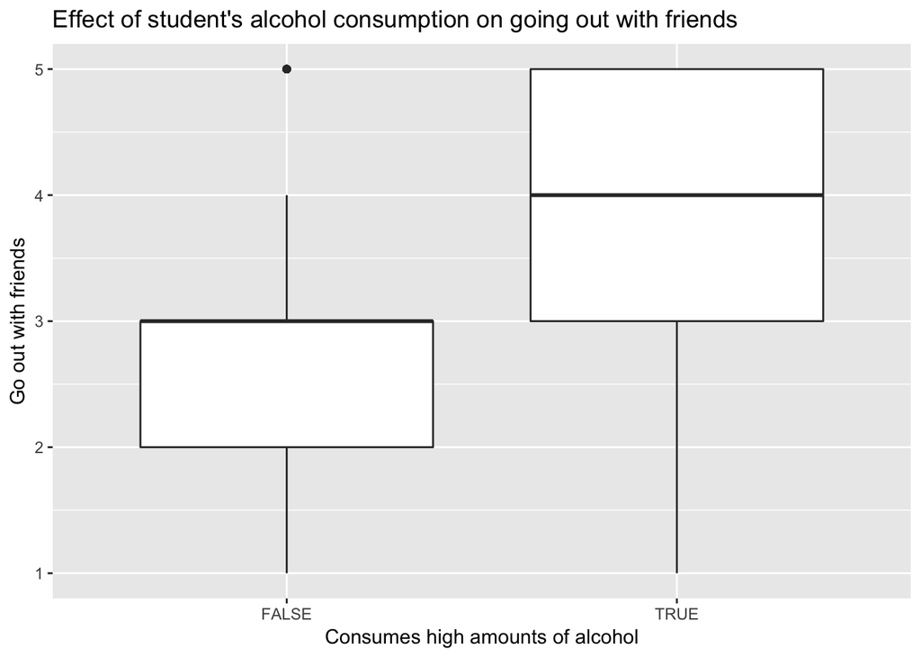

```r
g3<-ggplot(alc, aes(x=high_use, y=goout))
g3 + geom_boxplot() + ylab("Go out with friends")+xlab("Consumes high amounts of alcohol")+ggtitle("Effect of student's alcohol consumption on going out with friends")
```

Again it seems to have small logic, those who consume alcohol more, tend to spend more time out with their friends. So this time the TRUE group had higher points than the FALSE group (2.9 vs 3.7).

In the **data table 5** there are the mean values of the times they have been absent from the class with the same groups as previously (TRUE or FALSE on high alcohol consumption).

**Boxplot 4.** An effect of student’s alcohol consumption on times of absence from school.

```r
#access to libraries tidyr, dplyr and ggplot2.
library(tidyr); library(dplyr); library(ggplot2)

# What is the going out with friends in high/low consumer's group?
alc %>% group_by(high_use) %>% summarise(mean_grade=mean(absences))
```

```
## # A tibble: 2 × 2
##   high_use mean_grade
##      <lgl>      <dbl>
## 1    FALSE   3.705224
## 2     TRUE   6.368421
```

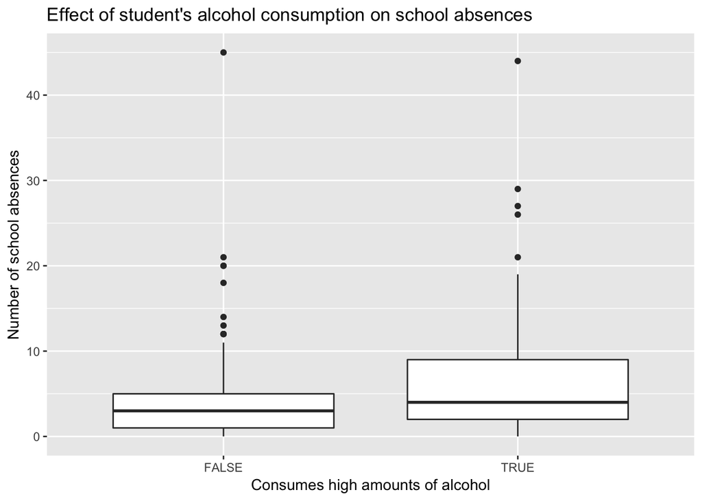

```r
g4<-ggplot(alc, aes(x=high_use, y=absences))
g4 + geom_boxplot() + ylab("Number of school absences")+xlab("Consumes high amounts of alcohol")+ggtitle("Effect of student's alcohol consumption on school absences")
```

Then the the relationships between the chosen variables and binary high/low alcohol consumption is explored statistically by logistic regression.

**Table 6.** The summary of fitted model and **Table 7.** the coefficients of the model.

```r
m<-glm(high_use~famrel+studytime+goout+absences, data=alc, family="binomial")
summary(m)
```

```
##
## Call:
## glm(formula = high_use ~ famrel + studytime + goout + absences,
##     family = "binomial", data = alc)
##
## Deviance Residuals:
##     Min       1Q   Median       3Q      Max
## -1.8701  -0.7738  -0.5019   0.8042   2.5416
##
## Coefficients:
##             Estimate Std. Error z value Pr(>|z|)
## (Intercept) -1.28606    0.70957  -1.812  0.06992 .
## famrel      -0.33699    0.13681  -2.463  0.01377 *
## studytime   -0.55089    0.16789  -3.281  0.00103 **
## goout        0.75953    0.12041   6.308 2.82e-10 ***
## absences     0.06753    0.02175   3.104  0.00191 **
## ---
## Signif. codes:  0 '***' 0.001 '**' 0.01 '*' 0.05 '.' 0.1 ' ' 1
##
## (Dispersion parameter for binomial family taken to be 1)
##
##     Null deviance: 465.68  on 381  degrees of freedom
## Residual deviance: 384.07  on 377  degrees of freedom
## AIC: 394.07
##
## Number of Fisher Scoring iterations: 4
```

```r
coef(m)
```

```
## (Intercept)      famrel   studytime       goout    absences
## -1.28606058 -0.33699130 -0.55089391  0.75953025  0.06753071
```

Also the logistic regression and coefficients of the model backs up the previous analysis. Coefficients are positive with the last two variables (goout and absences) but negative with the first ones (famrel) and (studytime).

Next the oddsratios and confidential intervals for the model are computed (**Table 8**).

```r
#compute oddratios and confidential intervals
OR<-coef(m)%>%exp
CI<-confint(m)%>%exp
#Print these out together
cbind(OR,CI)
```

```
##                    OR      2.5 %    97.5 %
## (Intercept) 0.2763573 0.06723596 1.0961732
## famrel      0.7139151 0.54460646 0.9331198
## studytime   0.5764343 0.41040872 0.7941804
## goout       2.1372720 1.69853389 2.7261579
## absences    1.0698631 1.02591583 1.1187950
```

Finally we are testing the predictive power of the model by 2x2 cross tabulation of predictions versus the actual values and predictions.

```r
#predict the probability of high_use
probabilities<-predict(m, type="response")

#add the predicted probabilities to alc
alc<-mutate(alc, probability=probabilities)

#use the probabilities to make a prediction of high use
alc<-mutate(alc, prediction=probability>0.5)

#Tabulate the target variable vs the predictions
table(high_use=alc$high_use, prediction=alc$prediction)
```

```
##         prediction
## high_use FALSE TRUE
##    FALSE   242   26
##    TRUE     65   49
```

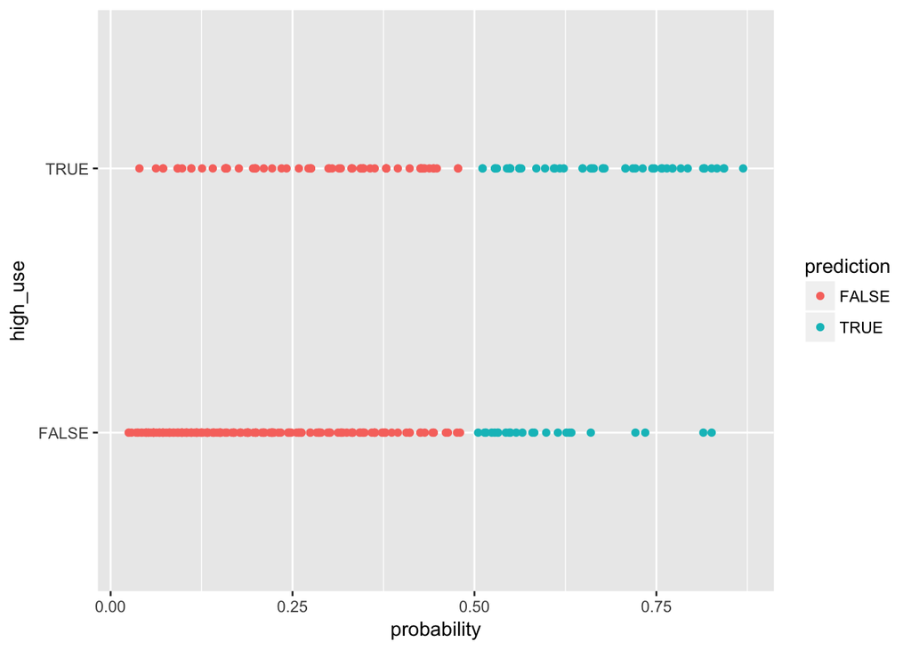

```r
#Initialize a plot of high use vs probability in alc
g<-ggplot(alc, aes(x=probability, y=high_use, col=prediction))

#Define the geom as point and draw the plot
g+geom_point()
```

```r
#Tabulate the target variable vs the predictions
table(high_use=alc$high_use, prediction=alc$prediction)%>% prop.table()%>%addmargins()
```

```
##         prediction
## high_use      FALSE       TRUE        Sum
##    FALSE 0.63350785 0.06806283 0.70157068
##    TRUE  0.17015707 0.12827225 0.29842932
##    Sum   0.80366492 0.19633508 1.00000000
```

Lastly, the total proportion of of inaccurately classified individuals (= the training error) is presented in the table below.

```r
#define mean prediction error
loss_func<-function(class, prob){
  n_wrong<-abs(class-prob)>0.5
  mean(n_wrong)
}
#Call loss_func to cumpute the average number of wrong predictions
loss_func(class=alc$high_use, prob=alc$probability)
```

```
## [1] 0.2382199
```